# Forecasting: Principles and Practice

## Residual diagnostics

Residuals are equal to the difference between the observations and the corresponding fitted values:

$$e_t = y_t - \hat{y}_t$$
They are useful to check whether a model has captured the information in the data (only white noise should be left in residuals). A good forecasting method yields residuals with the following properties:

- Residuals are uncorrelated.
- Residuals have zero mean.

In addition, it is useful but not necessary that:

- Residuals have constant variance
- Residuals are normally distributed.

The latter properties make the calculation of prediction intervals easier. Alternative approach to obtain prediction intervals may be necessary.

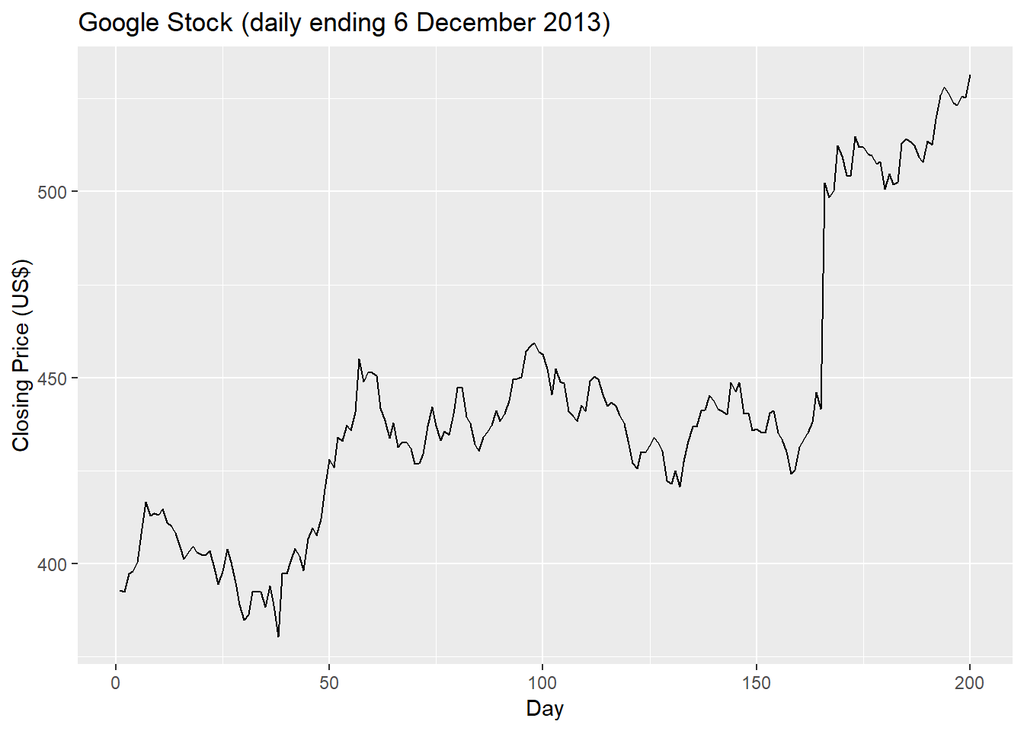

```r
autoplot(goog200) +
  xlab("Day") + ylab("Closing Price (US$)") +
  ggtitle("Google Stock (daily ending 6 December 2013)")
```

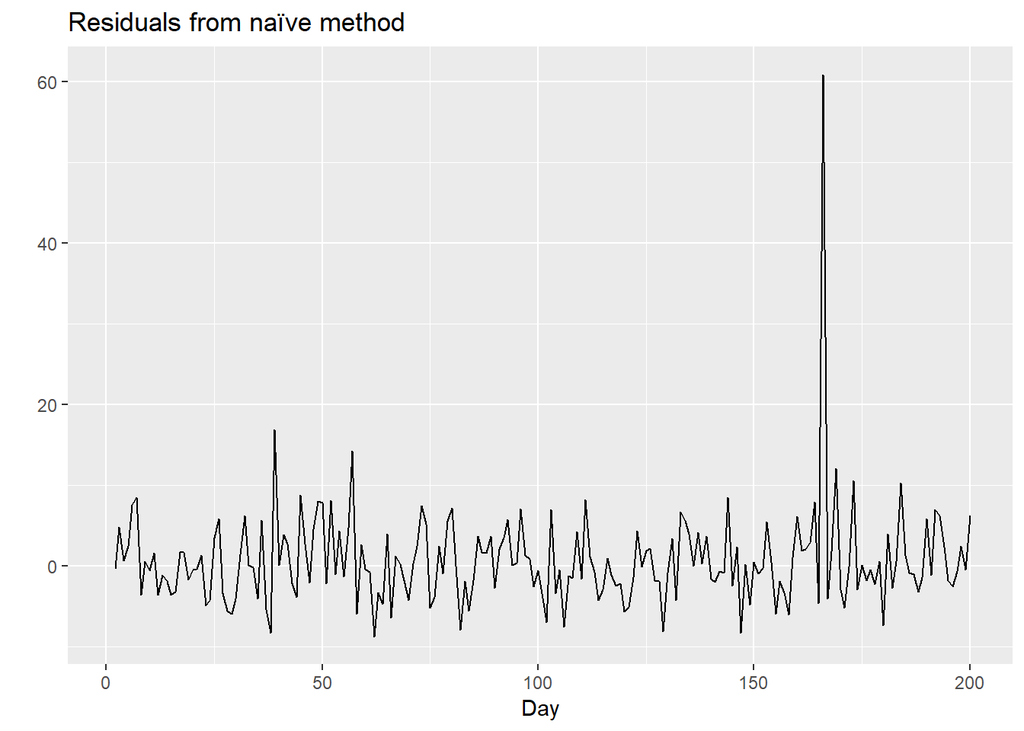

```r
# residuals
res <- residuals(naive(goog200))
autoplot(res) + xlab("Day") + ylab("") +
  ggtitle("Residuals from naïve method")
```

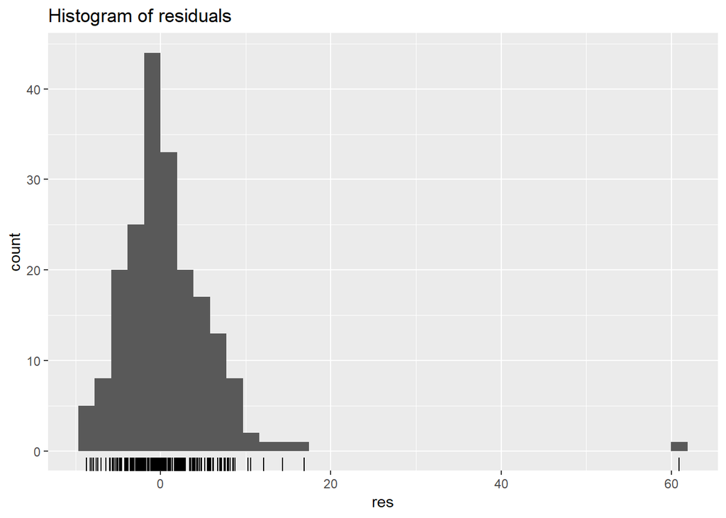

```r
# Histogram
gghistogram(res) + ggtitle("Histogram of residuals")
```

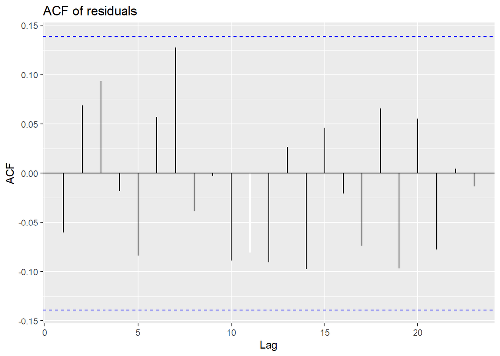

```r
ggAcf(res) + ggtitle("ACF of residuals")
```

#### Portmanteau test for autocorrelation

A test for a group of autocorrelations is called a portmanteau test. Common tests are the **Box-Pierce Test** and the **Ljung-Box test**. These are tesing whether the first h autocorrelations are significantly different from what would be expected from a white nois process.

Not significant results mean they are not distinguishable from a white noise process. Use the function `checkresiduals()`to produce a time plot of the residuals, ACF, histogram and a Ljung-Box test altogether.

## Evaluating forecast accuracy

Accuracy of forecasts can only be determined by considering how well a model performs on new data that were not used when fitting the model.

- Common practice to separate the available data into two portions, **training** and **test** data, where the training data is used to estimate any parameters of a forecasting method and the test data is used to evaluate its accuracy. Size of the test data is typically about 20% of the total sample.

Note:

- model which fis the training data well is not necessarily a good forecasting model
- Perfect fit can always be obtained by using a model with enough parameters.
- Over-fitting a model is just as bad as failing systematic patterns in the data.

#### Functions to subset a time series

```r
# window
my_beer <- window(ausbeer, start=1995)
str(ausbeer)
```

```
##  Time-Series [1:218] from 1956 to 2010: 284 213 227 308 262 228 236 320 272 233 ...
```

```r
str(my_beer)
```

```
##  Time-Series [1:62] from 1995 to 2010: 426 408 416 520 409 398 398 507 432 398 ...
```

```r
# subset
my_beer2 <- subset(ausbeer, start=length(ausbeer)-4*5)
str(my_beer2)
```

```
##  Time-Series [1:21] from 2005 to 2010: 403 408 482 438 386 405 491 427 383 394 ...
```

```r
#
my_beer3 <- subset(ausbeer, quarter=1)
head(my_beer3)
```

```
## Time Series:
## Start = 1956
## End = 1961
## Frequency = 1
## [1] 284 262 272 261 286 295
```

#### Forecast errors

Difference between actual realization and its forecast. Error may mean unpredictable part of an observation

$$e_{T+h} = y_{T+h} - \hat{y}_{T+h|T}$$

Different from residuals because:

- Residuals are calculated on the training set while forecast errors are calculated on the test set.
- Residuals are based on one-step forecasts while forecast errors can involve multi-step forecasts

#### Scale-dependent errors

scale-dependent errors can not be used to make comparisons between series of different units.

Common scale-dependent measures:

- Mean absolute error (MAE): $MAE=mean(|e_t|)$
- Root mean squared error (RMSE): $\sqrt{mean(e_t^2)}$

FOrecast method minimising the MAE will lead to forecasts of the median, while minimising the RMSE will lead to forecasts of the mean.

#### Percentage errors

Advantage of being unit-free

- Percentage error: $p_t = 100 \times (e_t / y_t)$
- Mean absolute percentage error (MAPE): $MAPE = mean(|p_t|)$

Those measures based on percentage errors have the disadvantage of being infinite or undefined if $y_t = 0$ for any t in the period of interest, and having extreme values if any $y_t$ is close to zero.

Another commonly used measure is the sMAPE (used in M3 for example). Hyndman & Koehler (2006) recommend that the sMAPE not be used.

#### Scaled errors

In the same paper scaled errors were proposed as alternative when **comparing forecast accuracy across series with different units**.

- How to: Scaling errors based on the *training MAE* from a simple forecast method.

For a non-sseasonal time series, useful way to define a scaled error uses naive forecasts:

$$q_j = \frac{e_j}{\frac{1}{T-1} \sum_{t=2}^T |y_t - y_{t-1}|}$$
where $y_t - y_{t-1}$ is the naive forecast error.

- Numerator and denominator both involve values on the scale of the original data, hence $q_j$ is independent of the scale of the data.
- Scaled error is less than one if it arises from a better forecast than the average naive forecast computed on the training data.
- It is greater than one if the forecast is worse than the average naive forecast computed on the training data.

For seasonal time series, a scaled error can be defined using seasonal naive forecasts:

$$q_j = \frac{e_j}{\frac{1}{T-m} \sum_{t=m+1}^T |y_t - y_{t-m}|}$$

and the mean absolute scaled error is simply:

$$MASE = mean(|q_j|)$$

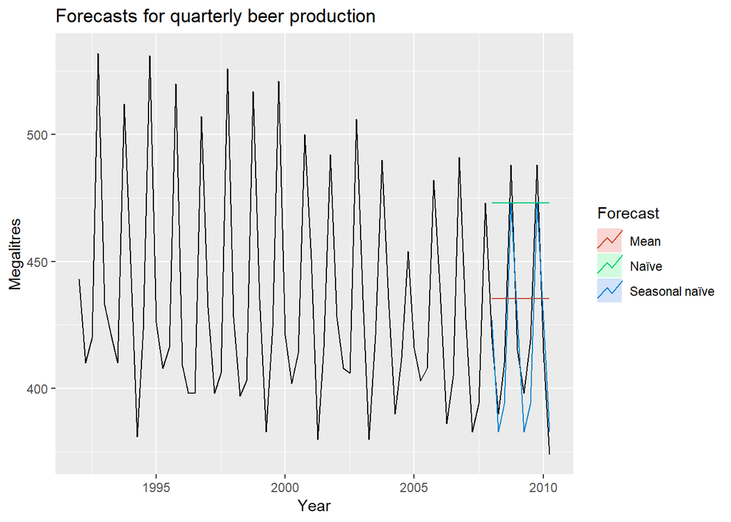

```r
# Seasonal Example
beer2 <- window(ausbeer,start=1992,end=c(2007,4))
beerfit1 <- meanf(beer2,h=10)
beerfit2 <- rwf(beer2,h=10)
beerfit3 <- snaive(beer2,h=10)
autoplot(window(ausbeer, start=1992)) +
  autolayer(beerfit1, series="Mean", PI=FALSE) +
  autolayer(beerfit2, series="Naïve", PI=FALSE) +
  autolayer(beerfit3, series="Seasonal naïve", PI=FALSE) +
  xlab("Year") + ylab("Megalitres") +
  ggtitle("Forecasts for quarterly beer production") +
  guides(colour=guide_legend(title="Forecast"))
```

```r
# accuracy
beer3 <- window(ausbeer, start=2008)
accuracy(beerfit1, beer3)[,c("RMSE","MAE", "MAPE","MASE")]
```

```
##                  RMSE      MAE     MAPE     MASE
## Training set 43.62858 35.23438 7.886776 2.463942
## Test set     38.44724 34.82500 8.283390 2.435315
```

```r
accuracy(beerfit2, beer3)[,c("RMSE","MAE", "MAPE","MASE")]
```

```
##                  RMSE      MAE     MAPE     MASE
## Training set 65.31511 54.73016 12.16415 3.827284
## Test set     62.69290 57.40000 14.18442 4.013986
```

```r
accuracy(beerfit3, beer3)[,c("RMSE","MAE", "MAPE","MASE")]
```

```
##                  RMSE  MAE     MAPE      MASE
## Training set 16.78193 14.3 3.313685 1.0000000
## Test set     14.31084 13.4 3.168503 0.9370629
```

For now, the seasonal naive method is best for these data (from graph and measures).

Nonseasonal example:

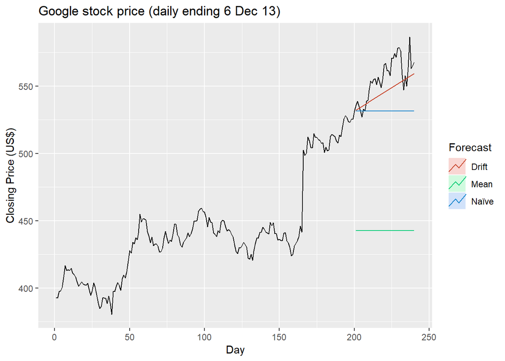

```r
googfc1 <- meanf(goog200, h=40)
googfc2 <- rwf(goog200, h=40)
googfc3 <- rwf(goog200, drift=TRUE, h=40)
autoplot(subset(goog, end = 240)) +
  autolayer(googfc1, PI=FALSE, series="Mean") +
  autolayer(googfc2, PI=FALSE, series="Naïve") +
  autolayer(googfc3, PI=FALSE, series="Drift") +
  xlab("Day") + ylab("Closing Price (US$)") +
  ggtitle("Google stock price (daily ending 6 Dec 13)") +
  guides(colour=guide_legend(title="Forecast"))
```

```r
# accuracy
googtest <- window(goog, start=201, end=240)
accuracy(googfc1, googtest)[,c("RMSE","MAE", "MAPE","MASE")]
```

```
##                   RMSE       MAE     MAPE      MASE
## Training set  36.91961  26.86941  5.95376  7.182995
## Test set     114.21375 113.26971 20.32230 30.280376
```

```r
accuracy(googfc2, googtest)[,c("RMSE","MAE", "MAPE","MASE")]
```

```
##                   RMSE       MAE      MAPE     MASE
## Training set  6.208148  3.740697 0.8437137 1.000000
## Test set     28.434837 24.593517 4.3599811 6.574582
```

```r
accuracy(googfc3, googtest)[,c("RMSE","MAE", "MAPE","MASE")]
```

```
##                   RMSE       MAE      MAPE     MASE
## Training set  6.168928  3.824406 0.8630093 1.022378
## Test set     14.077291 11.667241 2.0700918 3.119002
```

Here, the drift method seems to be the best among the three forecasts.

## Time series cross-validation

Series of test sets, each consisting of a single observation. The corresponding training set consists only of observations that occurred *prior* to the observation that forms the test set. Forecast accuracy is computed by averaging over the test sets.

- Also known as “evaluation on a rolling forecasting origin” because the “origin” at which the forecast is based rolls forward in time.

Cross-validation procedure can be modified to allow multi-step errors to be used (suppose we are interested in models that produce for example good 4-step-ahead forecasts).

Time series cross-validation is implemented with the `tsCV()` function.

```r
# Compare RMSE of time series cross validation with residual RMSE
e <- tsCV(goog200, rwf, drift = TRUE, h=1)
sqrt(mean(e^2, na.rm=TRUE))
```

```
## [1] 6.233245
```

```r
sqrt(mean(residuals(rwf(goog200, drift=TRUE))^2, na.rm=TRUE))
```

```
## [1] 6.168928
```

- RMSE from residuals is smaller, as the corresponding “forecasts” are based on a model fitted to the entire data set, rather than being true forecasts.
- Good way to choose the best forecasting model is to find the model with the smallest RMSE computed using time series cross-validation.

#### Pipe operator

```r
goog200 %>% tsCV(forecastfunction=rwf, drift=TRUE, h=1) -> e

e^2 %>%
  mean(na.rm=TRUE) %>%
  sqrt()
```

```
## [1] 6.233245
```

```r
goog200 %>% rwf(drift=TRUE) %>% residuals() -> res

res^2 %>%
  mean(na.rm=TRUE) %>%
  sqrt()
```

```
## [1] 6.168928
```

Note that with pipes it may seem more natural to use the right arrow assignment `->` rather than the left arrow.

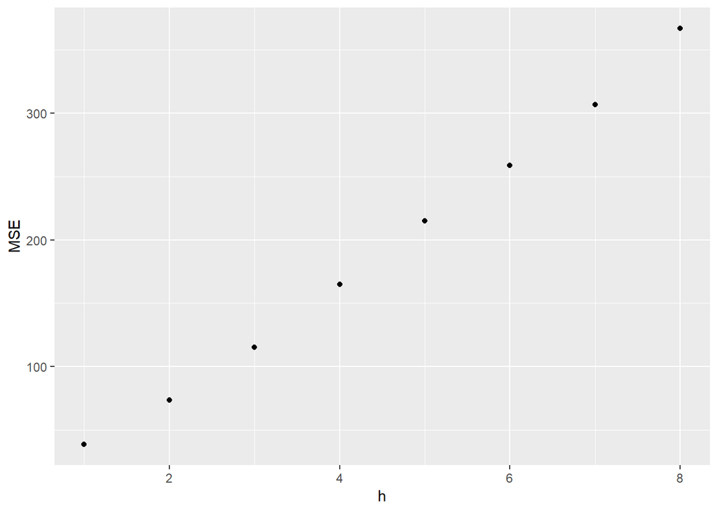

```r
# Example: using tsCV()
e <- tsCV(goog200, forecastfunction = naive, h=8)

# Compute MSE and remove missing values
mse <- colMeans(e^2, na.rm=TRUE)

# plot mse against forecast horizon
data.frame(h=1:8, MSE = mse) %>%
  ggplot(aes(x=h, y=MSE)) +
  geom_point()
```

## Prediction Intervals

PI givbes an interval within which we expect $y_t$ to lie with a specified probability.

Assuming the forecast errors are normally distributed, a 95% prediction interval for the h-step forecast is given by
$$\hat{y}_{T+h|T} \, \pm 1.96 \hat{\sigma}_h$$

where $\hat{\sigma}_h$ is an estimate of the standard deviation of the h-step forecast distribution.

If we only produce point forecasts, there is no way of telling how accurate the forecasts are. However, if we also produce prediction intervals, then it is clear how much uncertainty is associated with each forecast.

#### One-step prediction intervals

Almost the same as the standard deviation of the residuals for one step ahead predictions.

- No parameters (naive method): standard deviation is the same for forecast and residual

#### Multi-step prediction intervals

- PI usually increases as forecast horizon increases.
- Multi-step forecasts require a more complicatred method

#### Benchmark methods

Four benchmark methods to mathematically derive the forecast standard devaition under the assumption of uncorrelated residuals.

#### Prediction intervals from bootstrapped residuals

Assumption that forecst errors are normally distributed:

- Rewrite: $y_t = \hat{y}_{t|t-1}+ e_t$
- Simulate: $y_{T+1} = \hat{y}_{T+1|T} + e_{T+1}$

where $\hat{y}_{T+1|T}$ is the one-step forecast and $e_{T+1}$ the unknown future error. Assuming future errors will be similar to past errors, we replace these errors by sampling from the colleciton of errors we have seen in the past (i.e. residuals). In this way, we can simulate an entire set of future valus for our time series.

- Repeat: Doing this repeatedly, we obtain many possible futures from which we can computed prediction intervals by calculating percentiles for each forecast horizong.

```r
naive(goog200, bootstrap=TRUE, h=5)
```

```
##     Point Forecast    Lo 80    Hi 80    Lo 95    Hi 95
## 201       531.4783 526.0076 537.4780 523.2307 541.3329
## 202       531.4783 523.1219 539.1888 519.6461 546.8171
## 203       531.4783 520.9796 541.3019 516.6576 551.5067
## 204       531.4783 519.4217 543.1265 514.3001 558.5641
## 205       531.4783 517.6835 544.9892 511.5155 577.5225
```

If transformation has been used, prediction interval should be computed on the transformed scale, and the end points back-transformed to give a prediction interval on the original scale. Back-transforamtion is done autocamitally using the functions in the **forecast** package.

## The forecast package in R

Many functions of this package produce output of class `forecast`. This object contains information about forecasting method, data used, point forecasts obtained, PI, residauls and fitted values.

Functions designed to work with these objects:

- `autoplot()`
- `summary()`
- `print()`

List of all functions that produce `forecast`objects:

- `meanf()`
- `naive(), snaive()`
- `rwf()`
- `croston()`
- `stlf()`
- `ses()`
- `holt(), hw()`
- `splinef()`
- `thetaf()`
- `forecast()`

#### `forecast()` function

We have used functions which produce a `forecast()`object directly. More common approach:

- fit a model to the data
- use the `forecast()` function to produce forecats

Uses automatic ETS algorithm if first argument is of class `ts` (hence if it is not already a forecast model).

```r
# blind model
forecast(ausbeer, h=4)
```

```
##         Point Forecast    Lo 80    Hi 80    Lo 95    Hi 95
## 2010 Q3       404.6025 385.8695 423.3355 375.9529 433.2521
## 2010 Q4       480.3982 457.5283 503.2682 445.4216 515.3748
## 2011 Q1       417.0367 396.5112 437.5622 385.6456 448.4277
## 2011 Q2       383.0996 363.5063 402.6930 353.1341 413.0651
```

## Exercises

1. Find an appropriate Box-Cox transformation in order to stabilise the variance

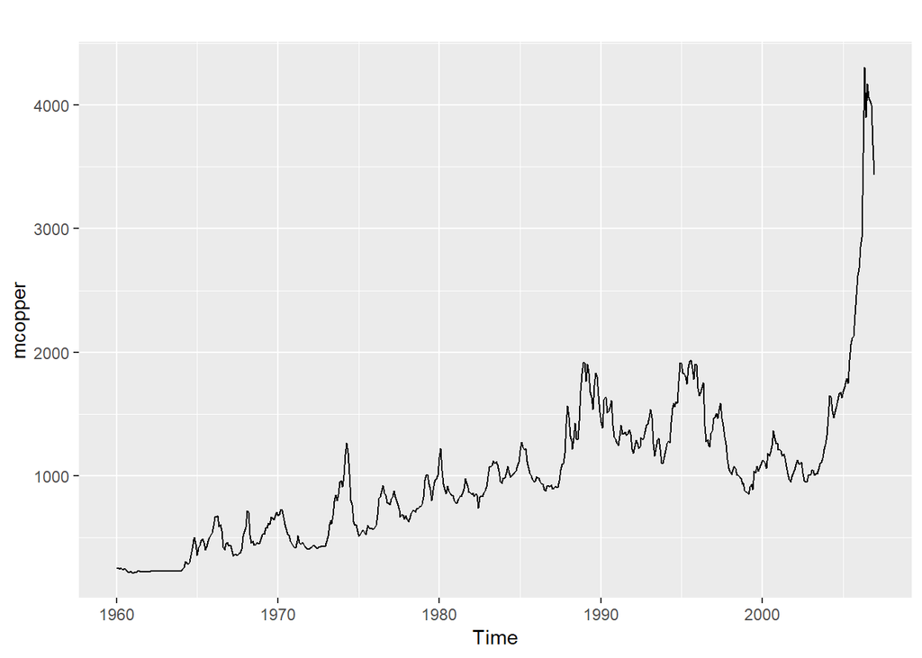

```r
# 1. Find appropriate Box-Cox transformation
autoplot(mcopper)
```

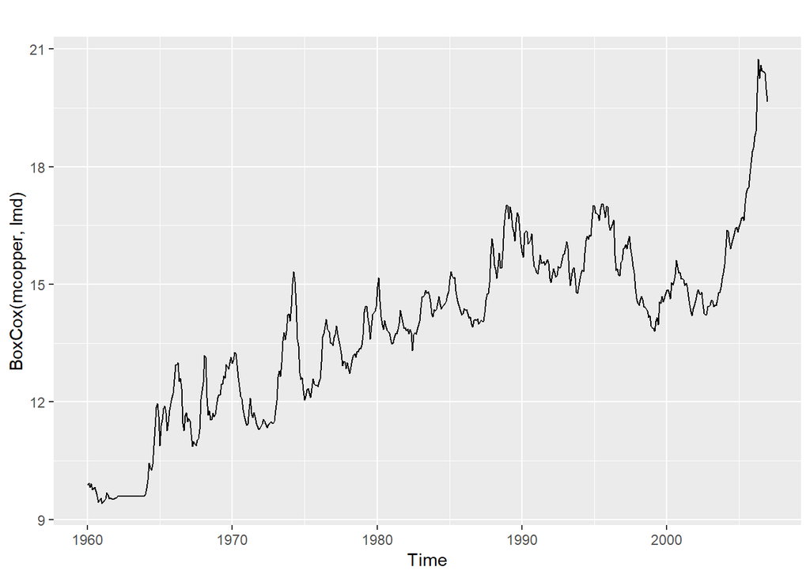

```r
lmd <-BoxCox.lambda(mcopper)
autoplot(BoxCox(mcopper, lmd))
```

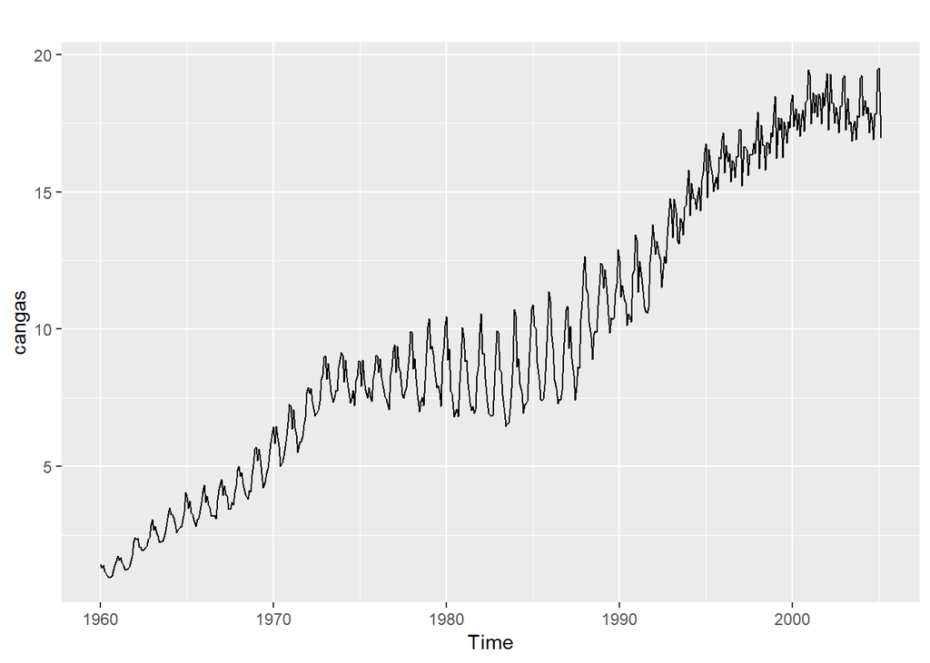

```r
# 2. Why BC unhelpful for cangas
autoplot(cangas)
```

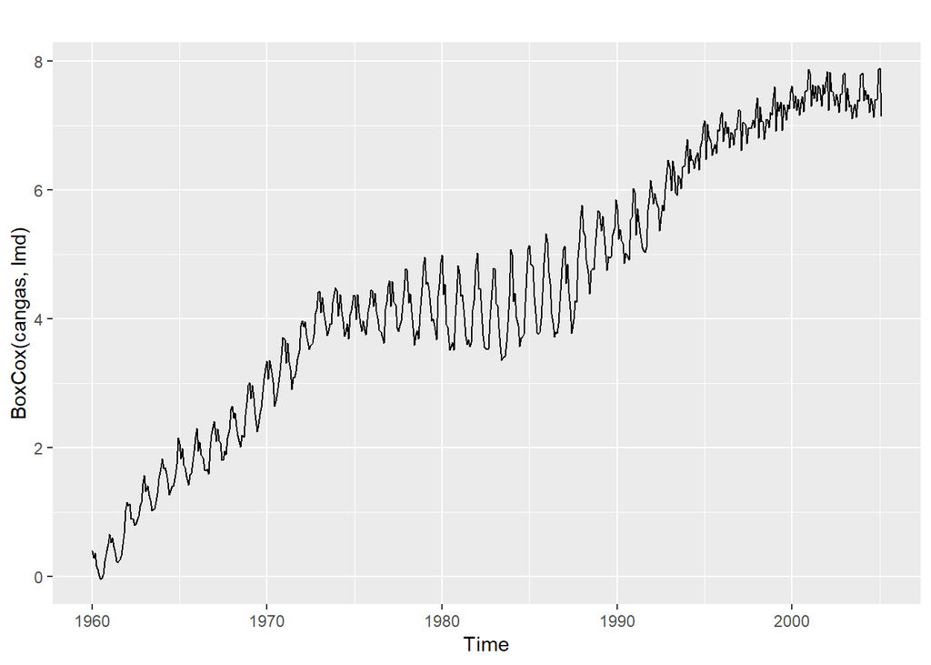

```r
lmd <- BoxCox.lambda(cangas)
autoplot(BoxCox(cangas, lmd))
```

As variance increases and then decreases there is no BoxCox transformation that can mimic this changing behavior of the series.

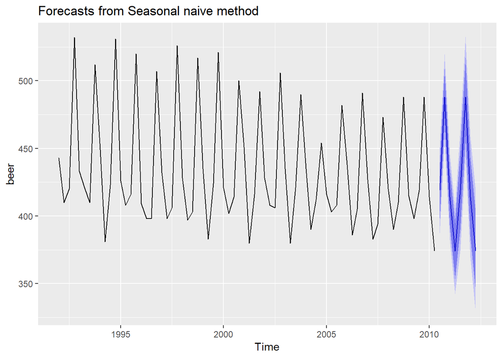

```r
# 5 Calculate residuals
beer <- window(ausbeer, start=1992)
fc <- snaive(beer)
autoplot(fc)
```

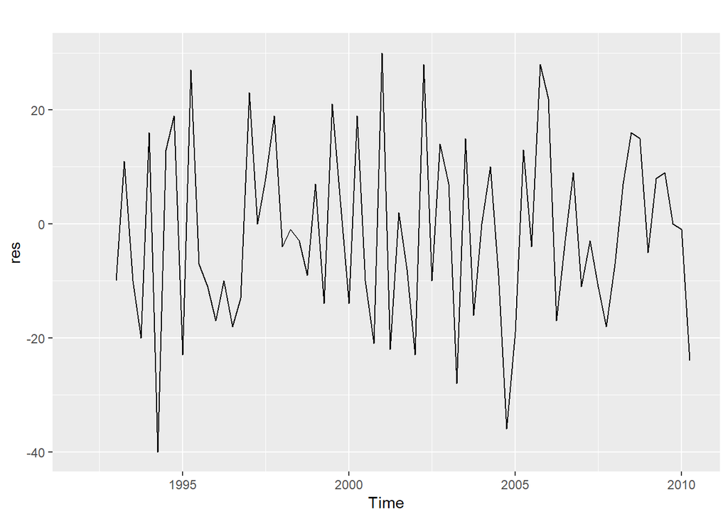

```r
res <- residuals(fc)
autoplot(res)
```

```r
#checkresiduals(res)
```

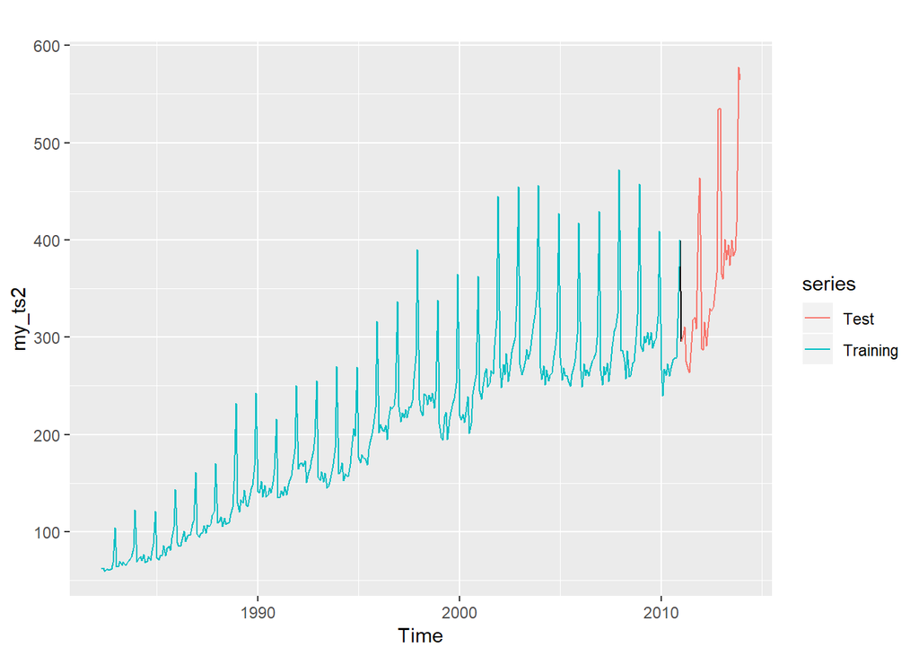

```r
# 8
myts.train <- window(my_ts2, end = c(2010, 12))
myts.test <- window(my_ts2, start = 2011)

autoplot(my_ts2) +
  autolayer(myts.train, series ="Training") +
  autolayer(myts.test, series = "Test")
```

```r
fc_snaive <- snaive(myts.train)
fc_arima <- forecast(auto.arima(myts.train))
fc_ets <- forecast(ets(myts.train))
fc_tbats <- forecast(tbats(myts.train))

fc_comb1 <- 0.5*(fc_arima$mean + fc_ets$mean)
fc_comb2 <- (1/3)*(fc_snaive$mean + fc_arima$mean + fc_ets$mean)
fc_comb3 <- (1/3)*(fc_snaive$mean + fc_ets$mean + fc_tbats$mean)

accuracy(fc_snaive, myts.test)[,c("RMSE","MAE", "MAPE","MASE")]
```

```
##                  RMSE      MAE      MAPE     MASE
## Training set 20.24576 15.95676  8.109777 1.000000
## Test set     71.44309 55.78333 15.082019 3.495907
```

```r
accuracy(fc_arima, myts.test)[,c("RMSE","MAE", "MAPE","MASE")]
```

```
##                  RMSE       MAE      MAPE      MASE
## Training set 10.94388  7.608542  3.661685 0.4768226
## Test set     87.48086 72.904829 20.231561 4.5689002
```

```r
accuracy(fc_ets, myts.test)[,c("RMSE","MAE", "MAPE","MASE")]
```

```
##                   RMSE       MAE      MAPE      MASE
## Training set  9.010034  6.344188  3.114127 0.3975863
## Test set     71.165015 56.161016 15.425890 3.5195759
```